# Target Users Analysis

```python
import pandas as pd
import numpy as np
import matplotlib.pyplot as plt
import os

import sys
sys.path.append("..")

from src.data_management.RecSys2019Reader import RecSys2019Reader
```

```python
df_target = pd.read_csv("../data/data_target_users_test.csv")
```

```python
df_target.head()
```

|  | user_id |
| --- | --- |
| 0 | 0 |
| 1 | 1 |
| 2 | 2 |
| 3 | 4 |
| 4 | 5 |

```python
target_users = df_target.user_id.values
target_users
```

```
array([    0,     1,     2, ..., 30908, 30909, 30910])
```

```python
print("There are %d users in the target users"%len(target_users))
```

```
There are 28106 users in the target users
```

## Analyze target users w.r.t. URM

```python
dataset = RecSys2019Reader()
dataset.load_data()
```

```
RecSys2019Reader: WARNING --> There is no verification in the consistency of UCMs
RecSys2019Reader: WARNING --> The number of data in UCM is much lower than the original
RecSys2019Reader: WARNING --> UCM will be ignored by any preprocessing or data splitter class
DataReader: Verifying data consistency...
DataReader: Verifying data consistency... Passed!
DataReader: current dataset is: <class 'src.data_management.RecSys2019Reader.RecSys2019Reader'>
	Number of items: 18495
	Number of users: 27255
	Number of interactions in URM_all: 398636
	Interaction density: 7.91E-04
	Interactions per user:
		 Min: 1.00E+00
		 Avg: 1.46E+01
		 Max: 6.77E+02
	Interactions per item:
		 Min: 0.00E+00
		 Avg: 2.16E+01
		 Max: 8.99E+02
	Gini Index: 0.54
```

```python
URM_all = dataset.get_URM_all()
URM_all
```

```
<27255x18495 sparse matrix of type '<class 'numpy.float64'>'
	with 398636 stored elements in Compressed Sparse Row format>
```

```python
URM_user_mapper = dataset.get_user_original_ID_to_index_mapper()
original_users_URM = list(URM_user_mapper.keys())
```

```python
mask = np.in1d(target_users, original_users_URM, assume_unique=True)
missing_users = target_users[~mask]
missing_users
```

```
array([   20,    23,    24, ..., 30901, 30902, 30907])
```

```python
print("There are %d missing users w.r.t. URM users"%len(missing_users))
```

```
There are 3656 missing users w.r.t. URM users
```

Are there users in URM but not in target test users?

```python
mask = np.in1d(original_users_URM, target_users, assume_unique=True)
URM_users_but_not_target = np.array(original_users_URM)[~mask]
URM_users_but_not_target
```

```
array(['3', '37', '38', ..., '30883', '30887', '30903'], dtype='<U5')
```

```python
print("Yes, there are %d users in URM but not in target"%len(URM_users_but_not_target))
```

```
Yes, there are 2805 users in URM but not in target
```

## How many users can we train with Early Stopping (i.e. dropping validation set)?

Let's suppose we do a leave-3-out splitting of the training. How many users are still warm, i.e. still have a sample in the training set?

```python
user_activity = (URM_all > 0).sum(axis=1)
user_activity = np.array(user_activity).squeeze()
len(user_activity)
```

```
27255
```

```python
users_trainable = user_activity[user_activity > 3]
print("Basically, there are only %d users in the training set"%(len(users_trainable)))
```

```
Basically, there are only 20743 users in the training set
```

Overall, since there are many users with a small user profile, dropping the validation set may loses the prediction of many users, but most of them were very difficult to predict with only so few data. So, still using a non-personalized recommender, clusterize those users in a group and recommend the same items of that group might be a solution or recommend very similar items to the small user profile

## Analyze missing users in target with users demographics (i.e. age and region)

### Region

```python
df_region = pd.read_csv("../data/data_UCM_region.csv")
df_region.head()
```

|  | row | col | data |
| --- | --- | --- | --- |
| 0 | 0 | 6 | 1.0 |
| 1 | 0 | 0 | 1.0 |
| 2 | 1 | 7 | 1.0 |
| 3 | 1 | 0 | 1.0 |
| 4 | 2 | 5 | 1.0 |

```python
users_UCM_region = df_region.row.values
```

```python
mask = np.in1d(missing_users, users_UCM_region, assume_unique=True)
missing_users_in_UCM_region = missing_users[~mask]
missing_users_in_UCM_region[:10]
```

```
array([ 20,  86,  87, 238, 389, 505, 511, 548, 577, 614])
```

```python
print("There are still missing %d users considering UCM region"%len(missing_users_in_UCM_region))
print("Which means there are %d missing users that can be handled by UCM region"%(len(missing_users)-len(missing_users_in_UCM_region)))
```

```
There are still missing 552 users considering UCM region
Which means there are 3104 missing users that can be handled by UCM region
```

Let's plot the region of these 3104 missing users:

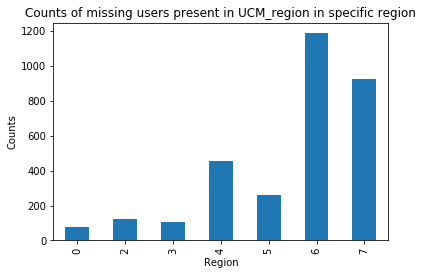

```python
df_region[df_region.row.isin(missing_users[mask])].col.value_counts().sort_index().plot.bar()
plt.title('Counts of missing users present in UCM_region in specific region')
plt.xlabel('Region')
plt.ylabel('Counts')
plt.show()
```

### Age

```python
df_age = pd.read_csv("../data/data_UCM_age.csv")
df_age.head()
```

|  | row | col | data |
| --- | --- | --- | --- |
| 0 | 2 | 4 | 1.0 |
| 1 | 7 | 10 | 1.0 |
| 2 | 8 | 4 | 1.0 |
| 3 | 10 | 4 | 1.0 |
| 4 | 12 | 4 | 1.0 |

```python
users_UCM_age = df_age.row.values
```

```python
mask = np.in1d(missing_users, users_UCM_age, assume_unique=True)
missing_users_in_UCM_age = missing_users[~mask]
missing_users_in_UCM_age
```

```
array([   24,  1606,  2601,  3566,  5541,  5690,  5745,  5764,  6071,
        6072,  6075,  6449,  6455,  6482,  6554,  6566,  6616,  6692,
        6768,  6821,  6825,  6896,  6905,  6986,  7019,  7033,  7113,
        7115,  7149,  7250,  7503,  7570,  7647,  8036,  8058,  8610,
        8884,  9907, 10177, 10310, 10435, 10493, 10515, 10752, 10788,
       10859, 10877, 10910, 17351, 17352, 17502, 17799, 17851, 20130,
       20551, 20559, 20578, 20581, 20586, 20605, 20611, 20658, 20663,
       20674, 20706, 24212, 24750, 24751, 24888, 25697, 26007, 26306,
       26973, 27630, 28308, 28861, 28862])
```

```python
print("There are still missing %d users considering UCM age"%len(missing_users_in_UCM_age))
print("Which means there are %d missing users that can be handled by UCM age"%(len(missing_users)-len(missing_users_in_UCM_age)))
```

```
There are still missing 77 users considering UCM age
Which means there are 3579 missing users that can be handled by UCM age
```

Let's plot the age for the missing users in UCM age:

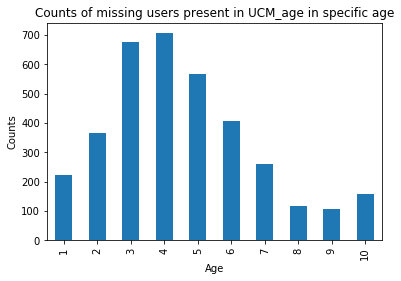

```python
df_age[df_age.row.isin(missing_users[mask])].col.value_counts().sort_index().plot.bar()
plt.title('Counts of missing users present in UCM_age in specific age')
plt.xlabel('Age')
plt.ylabel('Counts')
plt.show()
```

### Both Region and Age

```python
users_UCM_age_region = np.intersect1d(users_UCM_age, users_UCM_region)
users_UCM_age_region
```

```
array([    2,     7,    10, ..., 30904, 30907, 30909])
```

```python
mask = np.in1d(missing_users, users_UCM_age_region, assume_unique=True)
missing_users_in_UCM_age_region = missing_users[~mask]
missing_users_in_UCM_age_region[:10]
```

```
array([ 20,  24,  86,  87, 238, 389, 505, 511, 548, 577])
```

```python
print("There are still missing %d users considering UCM age"%len(missing_users_in_UCM_age_region))
print("Which means there are %d missing users that can be handled by UCM age"%(len(missing_users)-len(missing_users_in_UCM_age_region)))
```

```
There are still missing 629 users considering UCM age
Which means there are 3027 missing users that can be handled by UCM age
```

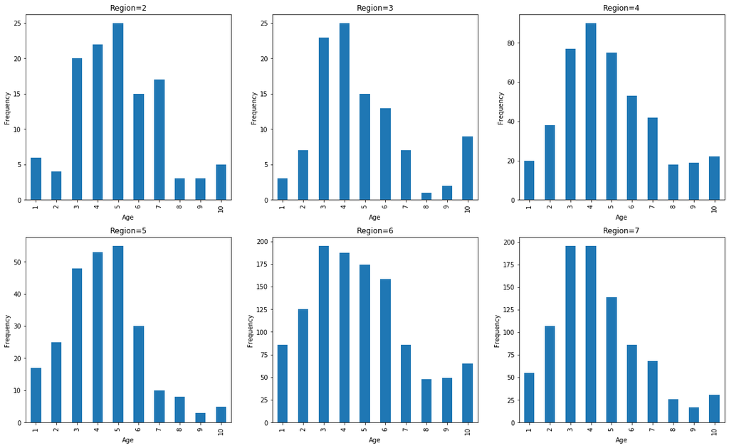

```python
df_age_region_missing = pd.merge(df_age, df_region, on='row')
df_age_region_missing = df_age_region_missing[df_age_region_missing.row.isin(missing_users[mask])]

regions = df_age_region_missing['col_y'].sort_values().unique()

fig, ax = plt.subplots(2, 3, figsize=(20, 12))

for i in range(len(regions)):
    df_age_region_missing[df_age_region_missing.col_y == regions[i]]['col_x'].\
            value_counts().sort_index().plot.bar(ax=ax[i//3][i%3])
    ax[i//3][i%3].set_xlabel('Age')
    ax[i//3][i%3].set_ylabel('Frequency')
    ax[i//3][i%3].set_title('Region=%d'%regions[i])
```

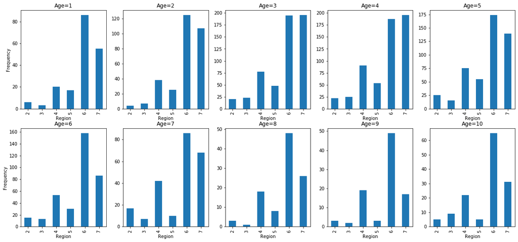

```python
ages = df_age_region_missing['col_x'].sort_values().unique()

fig, ax = plt.subplots(2, 5, figsize=(20, 9))

for i in range(len(ages)):
    df_age_region_missing[df_age_region_missing.col_x == ages[i]]['col_y'].\
            value_counts().sort_index().plot.bar(ax=ax[i//5][i%5])
    ax[i//5][i%5].set_xlabel('Region')
    if i%5==0:
        ax[i//5][i%5].set_ylabel('Frequency')
    ax[i//5][i%5].set_title('Age=%d'%ages[i])
```

## Conclusion

Overall, using demographics user information, it is possible to cover at most 3027 users with both age and region while leaving out 629 users that can be handled by non-personalized recommender or by using only information about the age (even a hybrid if possible). Then, leaving out 77 users that can be handled by non-personalized recommender.

Remember that these methods cannot be tested with validation set, because there is none. So, if you want it is only possible to test it via half-test set on Kaggle. This is just a gamble and you might overfit it when using information about demographics.

Moreover, it is possible to use the demographics for the small profile users: those not trainable

```python
users_not_trainable_mask = (user_activity > 0) & (user_activity <= 3)
users_not_trainable = np.array(original_users_URM)[users_not_trainable_mask]
users_not_trainable
```

```
array(['3', '8', '10', ..., '30897', '30898', '30903'], dtype='<U5')
```

```python
print("There are %d users not trainable and not in missing users"%len(users_not_trainable))
```

```
There are 6512 users not trainable and not in missing users
```

```python
mask = np.in1d(users_not_trainable, users_UCM_age_region, assume_unique=True)
users_not_trainable_in_UCM_age_region = users_not_trainable[~mask]
users_not_trainable_in_UCM_age_region
```

```
array(['3', '8', '19', ..., '30897', '30898', '30903'], dtype='<U5')
```

```python
print("There are still %d users not trainable and not in UCM age and region"%len(users_not_trainable_in_UCM_age_region))
```

```
There are still 1290 users not trainable and not in UCM age and region
```

In conclusion, there are different mixture of ways to handle it:

- Using ICM and try to find similar items for small user profiles
- Using UCM (i.e. user demographics) to find a group of similar users (i.e. by clustering, ...) and provide similar recommendations for users with empty user profiles
- Using non-personalized recommenders, i.e. Top-Popular (most easy way) for no user demographics

Non-personalized recommender can always be considered in some way, i.e. hybrid with UCM or ICM techniques